None

# Challenge

At the beginning of Reading 07, we attempted to scope the toy truck model as one single, monolithic free body, and we attempted to use dry Coulomb friction to model how the truck slowed. Quickly, we saw that this was inappropriate, given the viscous damping in the truck's bearings. A constant deceleration did **not** match what we observed in data. A reminder of what the truck's slow-down looked like is presented below.

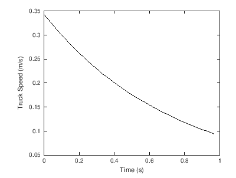

Because of this, we explored how to use Newton's Laws for rotating systems to develop a model for the truck's bearings. We then applied these techniques in order to model a simple pulley coasting down from an initial angular velocity in order to practice applying Newton's Laws for rotating systems to a simple phenomenon.

Now, let's reconsider our goal to model the truck's velocity as it coasts down, since the truck's bearings may be adequately modeled by an "idealized rotational damper." We will begin with another attempt to scope the model.

## Challenge: Model Scoping (again)

Because we have discovered that our original model scope was missing key information, we must revisit our process from the beginning, starting with scoping. The problem is not the overall system boundary, but the implication that we could treat the truck "monolithically" as one single element. We would do better to "pull out" key elements of our system until we expose the effects that define how our system behaves.

So, to unpack what is happening at the bearing interface between the truck's axles and its body, we will need to change our model scope. Specifically, we will need to treat three separate *elements* or subsystems in our model: the axles, the bearings, and the body of the truck. This is shown below:

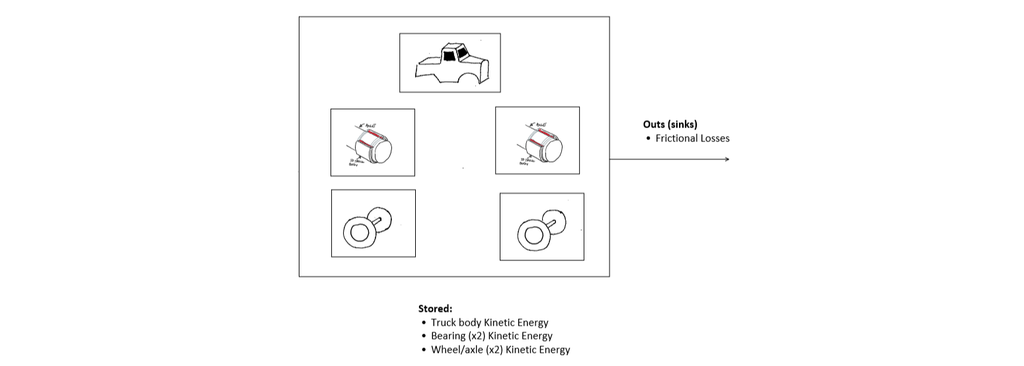

Note that the only material difference between the original system scope in Reading 07 is that we are now explicitly differentiating between energy (if any) stored in the wheels, the energy (if any) stored in the bearings, and energy stored in the truck body. Graphically, we are now separating the truck into its relevant components, each of which will need a free-body diagram if we are to approach the problem using Newton's laws. Recall that in Reading 07 we developed a formal disciplined process for applying Newton's Laws to obtain a system model.

Ultimately, we are **only** interested in the motion of the *body* of the truck. But in order to determine what its motion will be, we need to consider the motion of the body, the wheels/axles, and the bearings separately. Breaking the scope apart into discrete elements helps us see what interactions may be important in our system.

In fact, we can take advantage of the truck's apparent *symmetry* front to back, and only consider **half of it at a time**. Baked into this choice is the assumption that the truck's front and rear wheels are equally loaded, have similar inertial properties (mass and moment of inertia) and that the bearings have similar damping constants. Making this simplification will mean that we have to do far fewer free body diagrams, so if the data show us that this is an appropriate assumption in the Model Evaluation step, it will have been worth it.

An updated scope that only considers *HALF* of the truck is presented below.

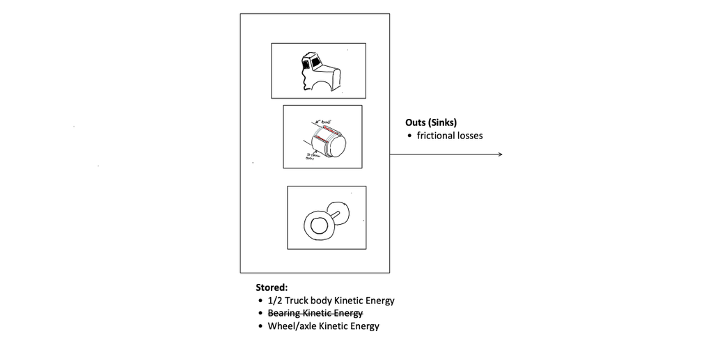

In addition to cutting the truck body in half, you will see that I also crossed out the bearing's kinetic energy. This is because in Reading 07, we derived a simple equation to describe idealized rotational dampers, and we said that many bearings satisfy the requisite assumption of negligible mass. With no mass, it is impossible for the bearing to store kinetic energy, which further simplifies our model. This is the scope we'll work with for now. If our assumption of symmetry is flawed, we may have to return to the more complex definition of our model scope above.

However, **before we construct our model**, note that we will need to be able to relate how the wheels on the truck *rotate* with how the truck *translates*. It should be clear **by watching the truck roll** that the rotation of the wheels is related to the velocity of the truck... but how? As it turns out, if we assume that the wheels *roll without slip*, we can relate rotation of the wheels to translation of the truck using the *arc length formula*. While you may have seen this before, the following section explains.

# Disciplined Process: relating rotational to translational motion under the assumption of roll without slip

When wheels roll without slip, we can use the [arc length formula](https://www.cuemath.com/geometry/arc-length/), which says that an arc length $s = r\theta$, where "r" is the radius of a circle and $\theta$ is the subtended angle, to help relate rotational and translational motion. This is helpful for analysis of belts, chains, pulleys, and wheels (when they are not skidding). To understand the arc-length formula, refer to the following figure, which shows string wrapped around a wheel unraveling as the wheel rolls along the ground.

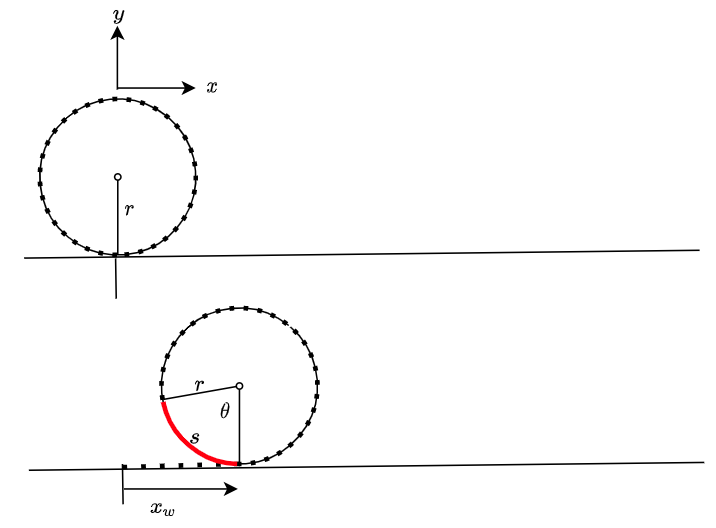

In this image, we can see that the amount of string that has unrolled is equal to the distance $x_w$ that the wheel's center has *translated*. This amount of string, $s$, is the "arc length" along the circle's surface that is swept by the angle $\theta$ that the wheel rolls. The way we've defined our coordinate system $x$ and $y$, we can use the right-hand rule to determine that counterclockwise angles $\theta$ are positive, while clockwise angles are negative. Noting that the wheel must roll clockwise to produce a positive $x_w$, we can write the equation:

$$x_w = -r\theta$$

If the circle's radius is a constant, we can take the time derivative of this equation to see that we can relate the wheel's velocity $v_w$ to the wheel's angular velocity $\omega$:

$$v_w = -r\omega$$

And again to see that we can relate the wheel's acceleration $a_w$ to the wheel's angular acceleration $\dot{\omega}$:

$$a_w = -r\dot{\omega}$$

# Challenge: Model Construction

Armed with our disciplined process for model construction and our new knowledge about roll-without-slip, we can begin our process of model construction with lists of key independent and dependent variables to help us keep track of what quantities we should see in our final equation. One thing to note is that based on our observation of the truck's behavior, we should be **expecting a differential equation**. Let's say for now that generally, this means we're looking for something like $\dot{v} = f(v)$ where $v$ represents the truck's velocity. Setting up this expectation now helps us stay oriented as we go.

As always, we will start with a list of independent variables. Think of this list as keeping track of what you need to know about each element in your system scope in order to fully describe the system's behavior. Note that as we go through the process of model construction, **these lists may change** as we discover more independent variables we'll need to measure in order to produce our final model!

**Independent variables:**

- time
- half of the truck chassis (body) inertia/mass $\frac{m_c}{2}$
- wheel/axle mass $m_w$
- wheel/axle moment of inertia $J_w$
- gravitational acceleration $g$
- bearing damping constant $b$
- Wheel radius $r$

Next, we'll look at a list of relevant dependent variables in our model. This list will usually be short-- what are we trying to get an equation *for?*

**Dependent variables:**

- truck acceleration $a = \dot{v} = \ddot{x}$
- truck velocity $v = \dot{x}$

Note that in the list above, $\dot{x}$ is used to denote $\frac{dx}{dt}$, and $\ddot{x}$ is used to denote $\frac{d^2x}{dt^2}$. The "dot" is a common notation for indicating time derivatives, and we will use it to keep equations that include derivatives easier to read.

Because we have numerical integration as a tool, we can focus our efforts on finding an equation for the dependent variable representing the *highest derivative* in our system. In this case, that's the acceleration of the truck body, $a = \dot{v} = \ddot{x}$. If we make it a goal to use Newton's laws to find an equation for $a$ in terms of only known quantities, we will be able to keep our eyes on the prize!

As we have done in the past, we will use the FBD of each element in our system as a guide for applying Newton's laws. A reminder of our disciplined process's step 3 (copied from Reading 07) can be found below. These are the steps we'll follow today.

## Disciplined Process: Using Newton's laws to obtain a mechanical system model

Step 3 of our disciplined process for Model Construction is to relate our model's independent and dependent variables. If we choose to use Newton's Laws to perform this step, we can create a differential equation to serve as a model for a system comprised of "idealized elements" such as masses and dampers by:

1. Drawing the FBD for each individual element in the system, indicating whether it meets the requirements for an idealized damper or an idealized mass.
2. Writing Newton's second law for each individual element in the system, using sums of forces ($\sum \vec{F} = m\vec{a}$) and/or torques ($\sum \vec{T} = J\vec{\dot{\omega}}$) as appropriate given the motion of your system. Be sure to apply Newton's 3rd law to link forces and torques between components (free bodies) in your system.
3. Eliminate all motion and force terms other than terms multiplied by the system's dependent variables (and their derivatives, as appropriate) using algebraic manipulation. Solving an equation for an unwanted term and substituting into another equation is a good way to eliminate the unwanted term.
4. Check to make sure that all terms multiplied by your model's dependent variables contain only known or measurable quantities (independent variables).
5. Check the model for internal validity by confirming that the units of each term are correct, that the signs match your intuition, and that the equation has the correct overall form.

## Model Construction continued: Free Body Diagrams and Newton's Second Law

Following the first step of our disciplined process to relate our independent and dependent variables, we can draw all of the forces and torques acting on each component of our model (as defined by our scope). The following diagrams use an $x$-right, $y$-up coordinate system, indicating that counterclockwise torques and angular velocities are positive (per the right-hand rule). Directions of forces are more-or-less based on my best guess for their directions based on an *assumed direction of motion*. However, consistency is more important than anything here-- if I draw the direction of a force or torque wrong, but stay consistent when applying Newton's Laws (2nd and 3rd), the signs will take care of themselves.

### Free Body Diagrams for the toy truck's components

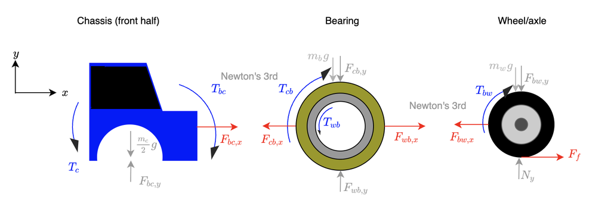

### Naming of Forces on the FBDs

Before we dive in to these FBDs, note that I have employed a systematic naming convention for forces and torques that are the result of one body acting on another. For example, the force $F_{bc,x}$ represents the Force **of the bearing (b) on the chassis (c)**. Similarly, The torque $T_{bc}$ represents the torque **of the bearing (b) on the chassis (c)**. These forces and torques are the result of the bodies being *attached* to one another, and Newton's third law says that if the bearing produces a force acting on the chassis, the chassis must act with an equal and opposite force on the bearing. The same applies to torques.

This means that there are already some easy equations we can use to *link the forces and torques between bodies!*. This will be useful shortly.

### Newton's 2nd Law Equations: Planning to complete step 2 of our disciplined process

1. The wheels *translate* in the x direction at the truck's velocity $v$, so we will need to write $\sum F_x = m_w \dot{v}$, where $m_w$ is the mass of the two front wheels and the axle.
2. The wheels *rotate* at some velocity $\omega_w$, so we will need to write $\sum T = J_w \dot{\omega_w}$, where $J_w$ is the moment of inertia of the truck's wheels and axle.
3. The bearing *translates* in the x direction at the truck's velocity $v$, so we will need to write $\sum F_x = m_b \dot{v}$, where $m_b \approx 0$ is the mass of the bearing. This assumption about $m_b$ is consistent with our discussion of idealized rotational dampers in Reading 07.
4. The bearing's inner race *rotates* at some velocity $\omega_w$ while the outer race does not (it is fixed to the non-rotating chassis), so we will need to write $\sum T = J_b \dot{\omega_w}$, where $J_b \approx 0$ is the moment of inertia of the bearing. This assumption about $J_b$ is consistent with our discussion of idealized rotational dampers in Reading 07.
5. The chassis *translates* in the x direction at the truck's velocity $v$, so we will need to write $\sum F_x = \frac{m_c}{2}\dot{v}$. Note that because of our assumption of symmetry, we will only write N2L for half of the truck's chassis' mass.

This means we have 5 equations to write rather than 9, which is a big savings! We will see how it goes.

### Newton's Second Law Equations for the bearing

Because we are going to model the bearing as an "idealized rotational damper," we have additional information about the forces and torques applied to it because we assume that its mass, and thus its moment of inertia, are zero. Based on the plan we laid out earlier, we need to sum the forces in the x direction and sum the torques as well for the bearing.

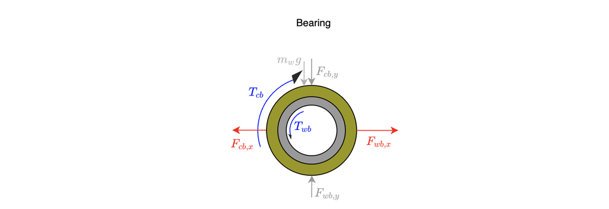

For example, we can say that in the translational x-direction: $$\sum F_x = \cancel{m_b} \dot {v} = F_{wb,x} - F_{cb,x}$$ Simplifying, we can say that:

$F_{wb,x} = F_{cb,x}$ (**EQN 1**)

Which means, in words, that the force exerted on the chassis by the bearing is **equal in magnitude but opposite in direction** to the force that the wheels exert on the bearing.

Because the bearing also rotates, we need to write N2L for rotational motion about the bearing's CG. If we can assume that the bearing acts like an idealized rotational damper, it means that its moment of inertia is zero:

$$\sum{T} = J_b \cancel{\dot{\omega}_b} = T_{wb} - T_{cb}$$

Simplifying, we see that:

$T_{wb}=T_{cb}$

But we also know from our discussion of idealized rotational dampers that the equal and opposite external torques *applied to* a bearing for which $\omega_1>\omega_2$ (where $\omega_1$ is the angular velocity of the outer race, and $\omega_2$ is the velocity of the inner race can always be written as:

$T_b = b(\omega_1 - \omega_2)$ assuming that $\omega_1>\omega_2$.

which gives us information about how the bearing's friction *resists* relative motion of the inner and outer races. If $\omega_1>\omega_2$ where counterclockwise rotation is positive, the bearing would have a positive (CCW) torque applied to the outer race, and a negative torque (CW) applied to the inner race.

**HOWEVER,** In our case, the outer race's angular velocity, $\omega_1=0$ because the outer race is fixed to the chassis of the truck. The inner race's angular velocity $\omega_2 = \omega_w$, where $\omega_w$ is the angular velocity of the wheel. This means that the way we drew this FBD, $\omega_2>\omega_1$, so **we must flip the signs in the equation above** so that $T_b = -b(\omega_1-\omega_2)$. If you are ever unsure about the signs, imagine yourself turning the bearing the way you drew the torques, and remember that friction always opposes motion.

Combining this information with what we got from the Newton's second law equation based on our FBD, we can write:

$T_{wb}=T_{cb}= b\omega_w$ (**EQN 2**)

In summary, our analysis of the bearing's FBD has yielded two equations we can use later:

1. $F_{wb,x} = F_{cb,x}$
2. $T_{wb}=T_{cb}= b\omega_w$

In these equations, we can see that $b$ is an inependent variable and $\omega_w$ is a dependent variable. We will work to eliminate all other terms from these equations once we have a full set!

### Newton's Second Law Equations for the Chassis's front half

The chassis and the wheel/axle are both connected to the bearing, so we could choose to analyze either next. The order in which we analyze our components is not particularly important. Based on the plan we laid out earlier, we need to sum the forces in the x-direction for the chassis. The chassis does not move in the y direction and does not rotate, so we are less likely to need equations based on these "static" (non-moving) dimensions.

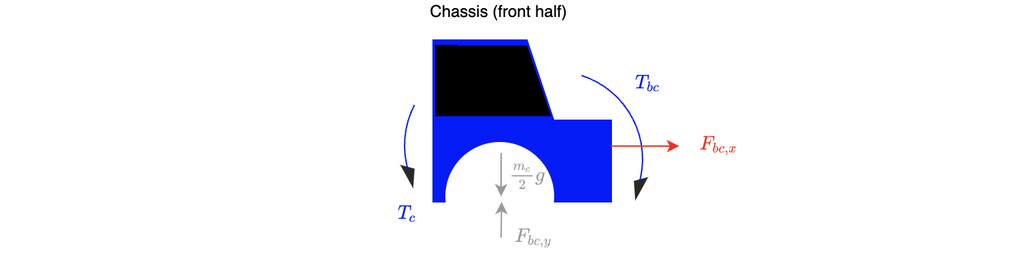

Noting that the only external force applied to the chassis's front half in the x-direction is from the bearing, we can write:

$\sum{F} = \frac{m_c}{2}\dot{v} = F_{bc,x}$

We can rearrange this to get the equation for our truck's *acceleration*, which we know is one of our dependent variables!!

1. $\dot{v} = \frac{2}{m_c}\cdot (F_{bc,x})$ (**EQN 3**)

This is great! However, it still includes an unknown force, $F_{bc,x}$, or the force exerted by the bearing on the truck chassis. This force is neither an independent variable nor a dependent variable, so we will want to eliminate it.

### Newton's Second Law equations for the Wheel and axle

The final component in our model scope is the wheel/axle combination. Based on the plan we laid out [earlier](https://jupytereng.lafayette.edu/user/brownaa/notebooks/ES103_SP22/source/Reading_08/Reading_08.html#Newton's-2nd-Law-Equations), we need to sum the torques about the wheel's CG and also sum the forces in the x direction.

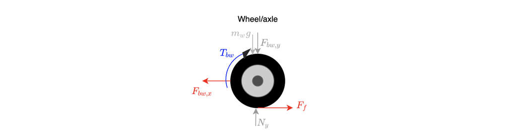

Beginning with the sum of forces in the x-direction, we get:

$\sum F_x = m_w \dot{v} = F_f - F_{bw,x}$

In this equation, $F_f$ is the friction force from the ground (outside of our system boundary) on the wheel's bottom edge. $F_{bw,x}$ is the force from the bearing on the wheel. Both of these forces are unknown! Hopefully we can eliminate them later when we work step 3 of our disciplined process for using Newton's laws in model construction.

We can rearrange this equation to get *yet another* equation describing the overall acceleration of the truck (because the truck and wheel both *translate* with the same motion).

1. $\dot{v} = \frac{1}{m_w}(F_f-F_{bw,x})$ (**EQN 4**)

Finally, we need to sum the torques about the wheel's center of mass. External torques are applied to the wheel from the *bearing* as a pure torque"), and also by the frictional force, which is applied *perpendicular* to the radius of the wheel! Recall that the right-hand rule tells us that counterclockwise torques are positive, and clockwise torques are negative.

$\sum T = J_w \dot{\omega_w} = F_f \cdot r - T_{bw}$

We can rearrange this equation to find the angular acceleration of the wheel as:

1. $\dot{\omega}_w = \frac{1}{J_w}(F_f \cdot r - T_{bw})$(**EQN 5**)

This means we have all 5 of the Newton's Second Law equations we expected given our [plan](https://jupytereng.lafayette.edu/user/brownaa/notebooks/ES103_SP22/source/Reading_08/Reading_08.html#Newton's-2nd-Law-Equations). We are ready to move on to Step 3 of our disciplined process for using Newton's laws in model construction.

## Eliminating unknown forces and torques in our Newton's Second Law equations

We have moved on to step 3 of our disciplined process for using Newton's laws for model construction, which involves looking at our list of N2L equations and manipulating them to eliminate unwanted (unknown) variables. We have used the FBD of each component in our system to derive the following 5 equations:

1. $F_{wb,x} = F_{cb,x}$ (**EQN 1**)
2. $T_{wb}=T_{cb}= b\omega_w$ (**EQN 2**)
3. $\dot{v} = \frac{2}{m_c}\cdot (F_{bc,x})$ (**EQN 3**)
4. $\dot{v} = \frac{1}{m_w}(F_f-F_{bw,x})$ (**EQN 4**)
5. $\dot{\omega}_w = \frac{1}{J_w}(F_f\cdot r - T_{bw})$(**EQN 5**)

Looking at these equations, we can recognize the following variables that are **neither** independent nor dependent variables. We will call these "unknowns" to be eliminated:

- $F_{wb,x}$ (force of wheel on bearing)
- $T_{wb}$ (torque of wheel on bearing)
- $T_{cb}$ (torque of chassis on bearing)
- $\omega_w$ (angular velocity of wheel)
- $\dot{\omega}_w$ (angular acceleration of wheel)
- $F_f$ (force of friction from ground on wheel)
- $F_{bc,x}$ (force of bearing on chassis)
- $F_{bw,x}$ (force of bearing on wheel)
- $T_{bw}$ (torque of bearing on wheel)

### Eiminating unknowns using geometry

We could begin immediately with algebraic manipulation, but we have more unknowns than equations! In order to eliminate them all, we would need the number of unknowns to be less than or equal to the number of equations we have. However, we can actually reduce our number of unknowns by two using our disciplined process for roll without slip. Using this, we can rewrite $\omega_w = \frac{-v}{r}$ and $\dot{\omega}_w = \frac{-\dot{v}}{r}$. With this substitution, our 5 equations become:

1. $F_{wb,x} = F_{cb,x}$ (**EQN 2**)
2. $T_{wb}=T_{cb}= -\frac{bv}{r}$ (**EQN 2**)
3. $\dot{v} = \frac{2}{m_c}\cdot (F_{bc,x})$ (**EQN 3**)
4. $\dot{v} = \frac{1}{m_w}(F_f-F_{bw,x})$ (**EQN 4**)
5. $\frac{-\dot{v}}{r} = \frac{1}{J_w}(F_f\cdot r - T_{bw})$(**EQN 5**)

### Eliminating unknowns using Newton's 3rd Law

Another strategy we can use for eliminating unknowns is to use Newton's 3rd Law, which states that for every action, there is an equal and opposite reaction. This approach allows us to equate forces and torques that are common between bodies. Thankfully, we already drew forces and torques between bodies as having opposite directions, so we can simply state the equivalence of their magnitudes. For example, $T_{wb}$, the torque from the wheel on the bearing, will be equal to $T_{bw}$, the torque from the bearing on the wheel! We can write a set of equations that reflect Newton's 3rd law for the torques and forces that link each of our elements.

- $T_{bw}=T_{wb}$ (bearing-wheel torque)
- $F_{bw}=F_{wb}$ (bearing-wheel force)
- $F_{cb}=F_{bc}$ (chassis-bearing force)

Making these substitutions leaves us with the following modified set of N2L equations:

1. $F_{wb,x} = F_{cb,x}$ (**EQN 1**)
2. $T_{wb}=T_{cb}=- \frac{bv}{r}$ (**EQN 2**)
3. $\dot{v} = \frac{2}{m_c}\cdot (F_{cb,x})$ (**EQN 3**)
4. $\dot{v} = \frac{1}{m_w}(F_f-F_{wb,x})$ (**EQN 4**)
5. $\frac{-\dot{v}}{r} = \frac{1}{J_w}(F_f\cdot r - T_{wb})$(**EQN 5**)

and the following remaining unknowns:

- $F_{wb}$ (wheel-bearing force)
- $T_{wb}$ (wheel-bearing torque)
- $F_{cb}$ (chassis-bearing force)
- $F_f$ (force of friction from ground on wheel)

This means that we should have enough equations to eliminate all unknowns! We are now ready to use algebraic manipulation.

### Eliminating remaining unknowns using algebraic manipulation

Now that we have exhausted our options for eliminating unknowns using Newton's 3rd law and any geometric constraints we have, we should be able to eliminate our remaining unknowns using algebra. To eliminate a variable, we can solve one of our 5 equations for it, and then substitute it into another! Let's try this. we can substitute EQN 2 into EQN 5. Then, EQN 5 becomes:

5a. $\frac{-\dot{v}}{r} = \frac{1}{J_w}(F_f\cdot r + b\frac{v}{r})$

Let's stick with EQN 5a, and look for other unknowns. We see that another unknown, $F_f$, appears in EQN 5a but also in EQN 4! We can therefore solve eqn 4 for $F_f$:

4a. $F_f = m_w\dot{v} + F_{wb,x}$

Then, we can substitute it into EQN 5a:

5b. $\frac{-\dot{v}}{r} = \frac{1}{J_w}((m_w\dot{v} + F_{wb,x})\cdot r + b\frac{v}{r})$

Still sticking with EQN 5b, we see that there is one remaining unknown, $F_{wb,x}$, left in the equation. Using EQN 1, we know that $F_{wb,x} = F_{cb,x}$, so we can actually use EQN 1 along with EQN 3 to find:

3a. $\dot{v}\frac{m_c}{2} = F_{wb,x}$

This can be substituted into 5b to obtain:

5c. $\frac{-\dot{v}}{r} = \frac{1}{J_w}((m_w\dot{v} + \dot{v}\frac{m_c}{2})\cdot r + b\frac{v}{r})$

We can collect all terms multiplied by $\dot{v}$ to obtain:

5d. $\dot{v}\left( \frac{J_w}{r} + m_w r + \frac{m_c r}{2} \right) = -\frac{b}{r} v$

This is an equation that **only has independent and dependent variables in it!!** If we solve it for $\dot{v}$, we can check the units of each term in the equation, confirm that the faster the truck goes, the faster it slows down, and confirm that it looks like a differential equation ala Reading 06.

Solving for $\dot{v}$ gives: $$\dot{v} = - \frac{1}{\left( \frac{J_w}{r} + {m_w r} + \frac{m_c r}{2} \right)}\frac{b}{r} v$$ To clean this up a bit, let's distribute the $r$ in the term $\frac{b}{r}$ into the denominator of the fraction, which will give us our final model.

$$\dot{v} = - \frac{1}{\left( J_w + m_w r^2 + \frac{m_c r^2}{2} \right)}b v$$